# What Plot?

## Number of downloads per day during a **single week**

what type of plot would you choose to visualize the data below?

| day | n |
| --- | --- |
| Mon | 90 |
| Tue | 56 |
| Wed | 58 |
| Thu | 64 |
| Fri | 45 |
| Sat | 29 |
| Sun | 58 |

**What plot?**

**Bar**

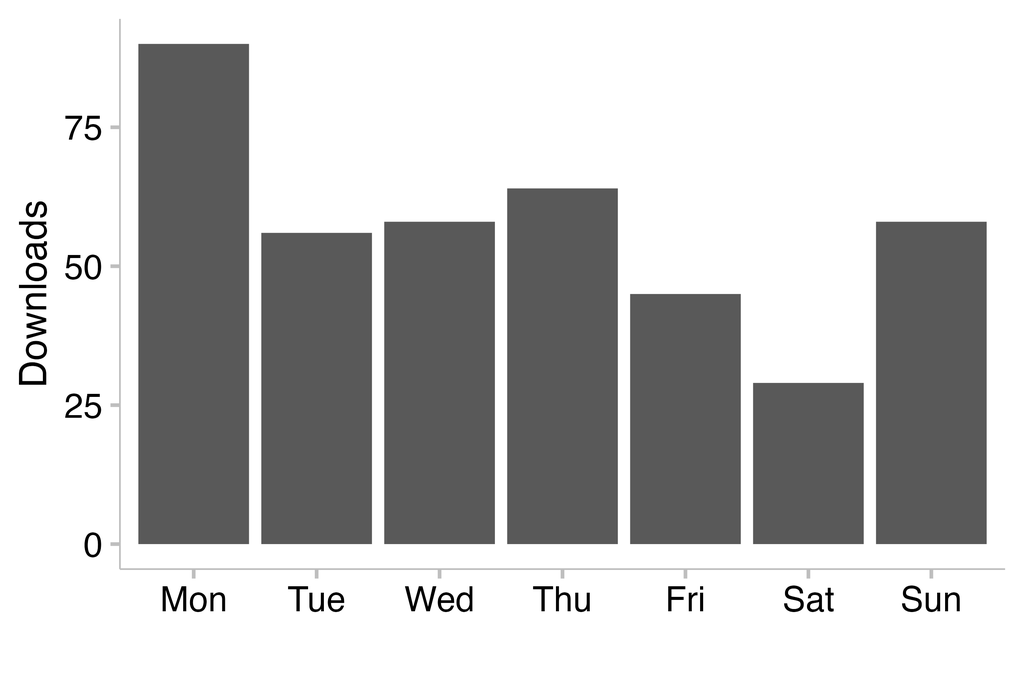

- Bar plot
  - good for counts
  - good for discrete point values
  - but why not just use a point?

**Point**

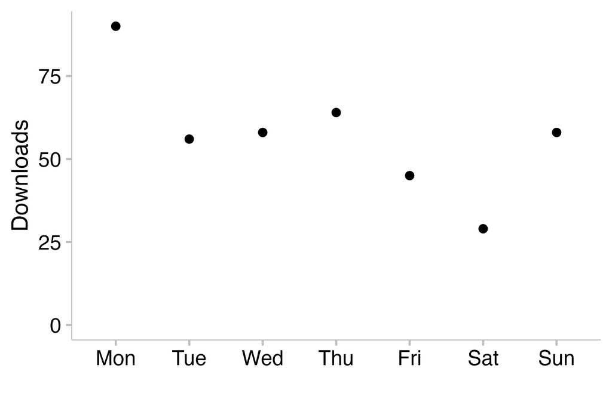

**Lollipop**

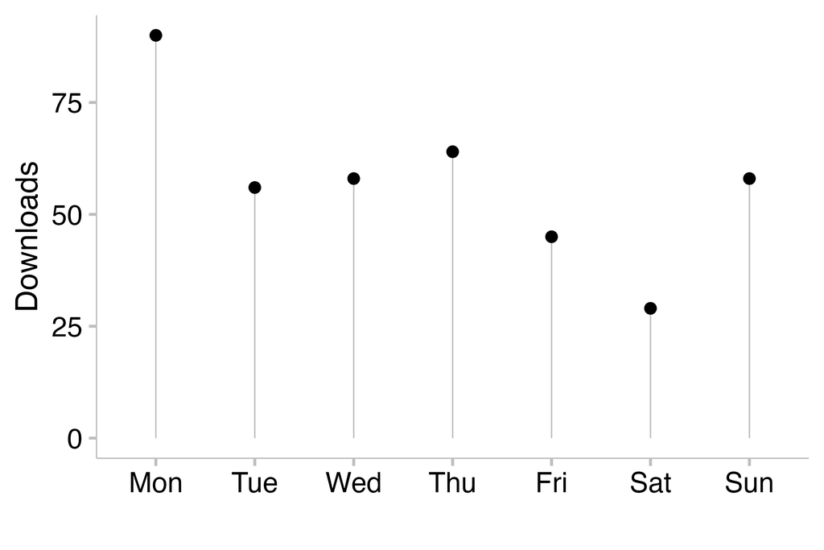

- Lollipop plot
  - Conveys *exactly* the same information as the bar plot.
  - helps reduce the “floatiness” of the points.
  - Again 0 should be included.
  - Works well with lots of points.

**Line**

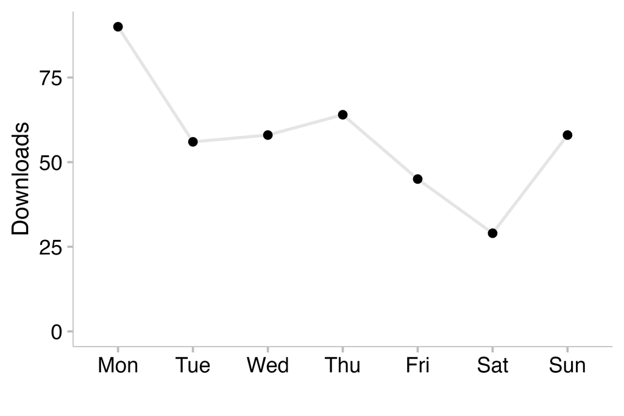

- Line plot
  - Connecting points with a line suggests the points follow a sequence, e.g. day order.

**Pie**

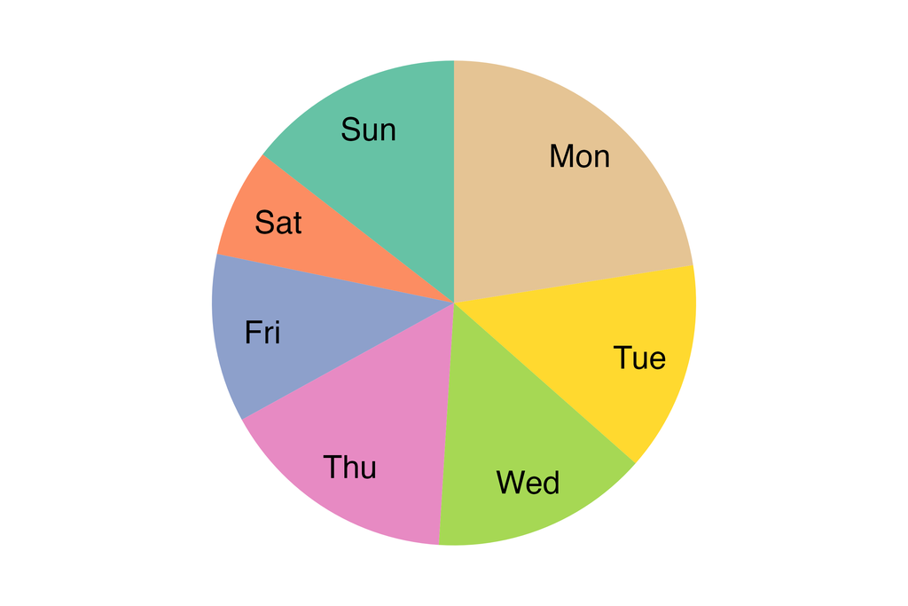

- Pie cahrt
  - Eww, yuck!
  - Too many categories.
  - Which is bigger: Tue, Wed, Thu, or Sun?
  - We are pretty decent at noticing deviations from straight / level
    - but pretty poor at putting a number on the deviation.

## Client age data

Here we have many values for each of three categories. The data show the ages of people downloading an app, from three different sectors. Each category has a different number of observations. Decide if we want to see every single observation or summarize in some way.

- N observations
  - Retail: 80
  - Construction: 50
  - Care: 30

| age | industry |
| --- | --- |
| 31 | retail |
| 53 | retail |
| 26 | retail |
| 27 | retail |
| 33 | retail |
| 46 | retail |
| 28 | retail |
| 35 | retail |
| 26 | retail |
| 33 | retail |

[output cut: 150 more lines]

**what plot?**

**Hist age**

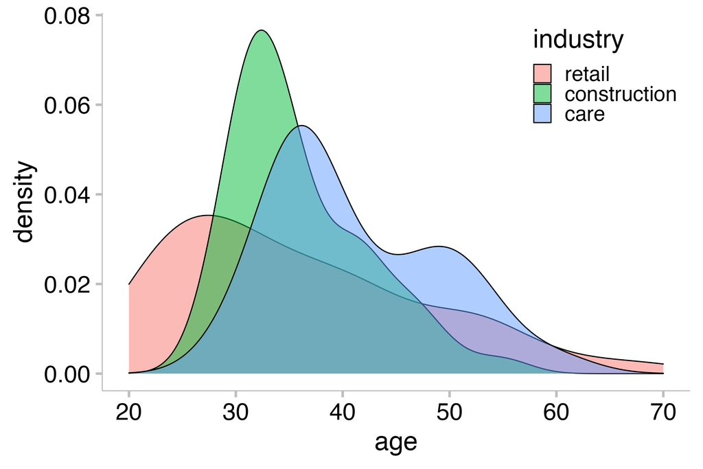

- Density plot
  - Good for visualizing distribution of continuous data
  - Nice to overlap if only a few categories

**Dotplot**

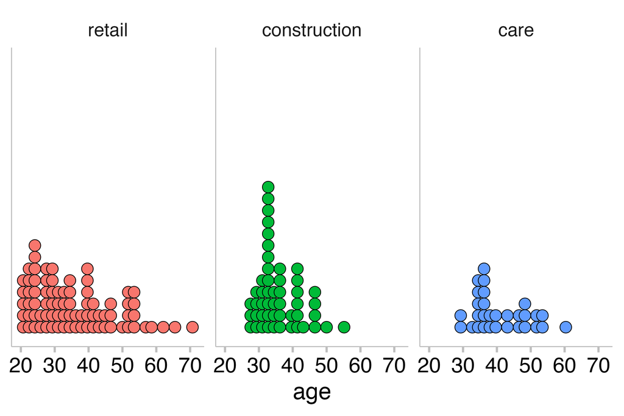

**Violin plot**

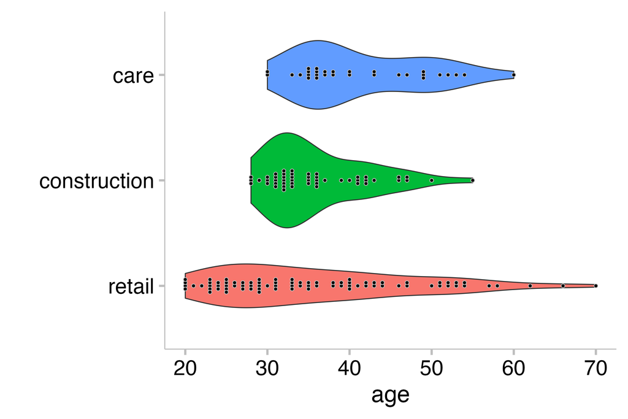

Violin plots convey more info than either bar plots or boxplots, especially if you show points.

This plot hints at a compelling story about how users from different industries use the app.

**Average summary bar chart**

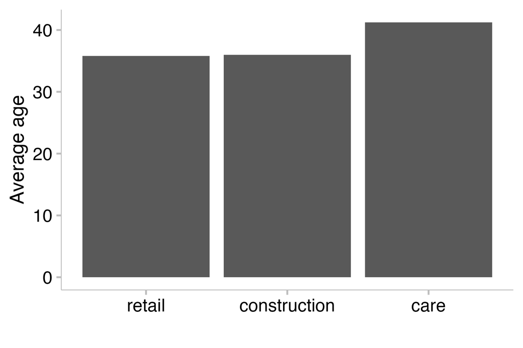

- Not a good choice for showing summaries
  - Too much information lost

**Boxlot**

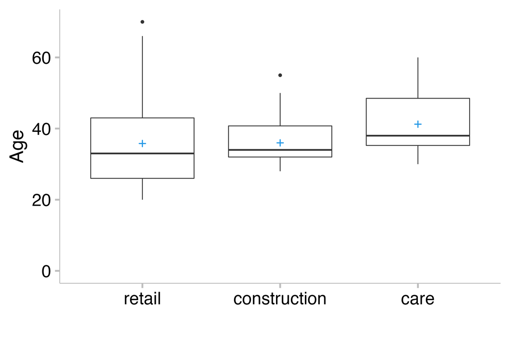

**Combo plot**

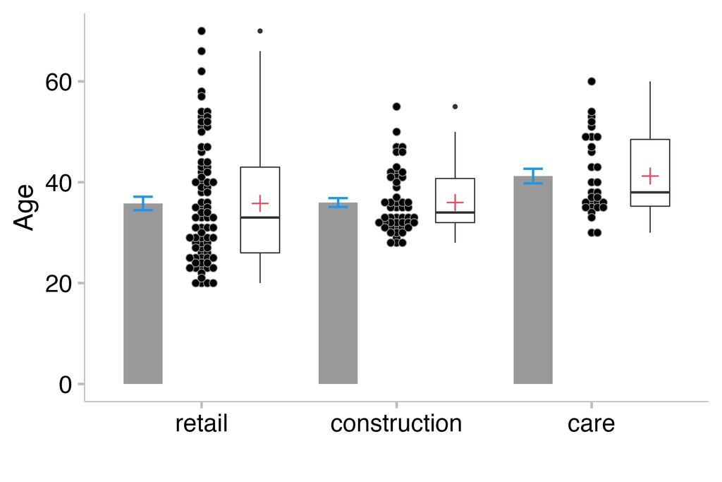

## Churn %age change

| year | churn |
| --- | --- |
| 2021 | 20 % |
| 2022 | 15 % |

**What plot?**

**Bar plot**

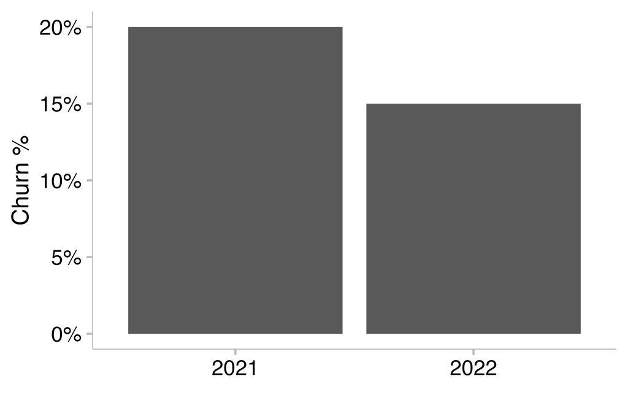

**Stacked bars as percent**

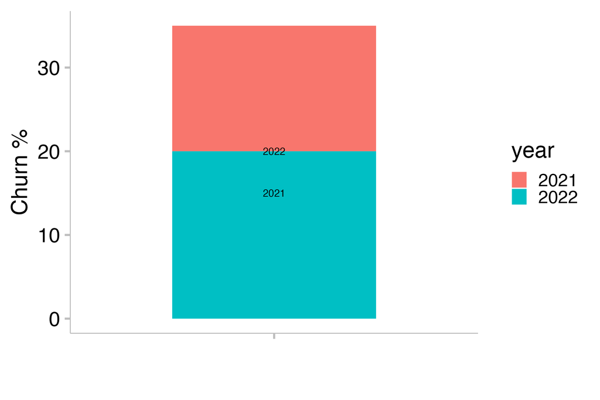

**Pie**

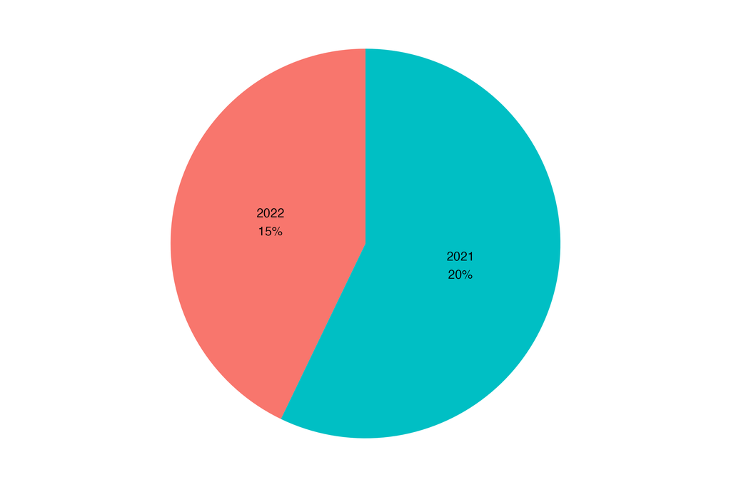

What’s wrong with this plot?

## Clients by industry

Using the same data as earlier, we want to get a better idea of the breakdown of industry types using our app.

Remember, in the full data there are:

- N observations
  - Retail: 80
  - Construction: 50
  - Care: 30

Here’s a recap of how it looks

| age | industry |
| --- | --- |
| 31 | retail |
| 53 | retail |
| 26 | retail |
| 39 | construction |
| 47 | construction |
| 33 | construction |
| 36 | care |
| 35 | care |
| 60 | care |

**What plot?**

**Bar plot - Count**

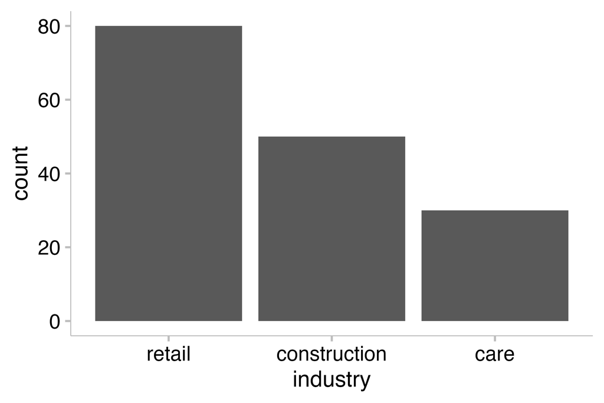

**Stacked count**

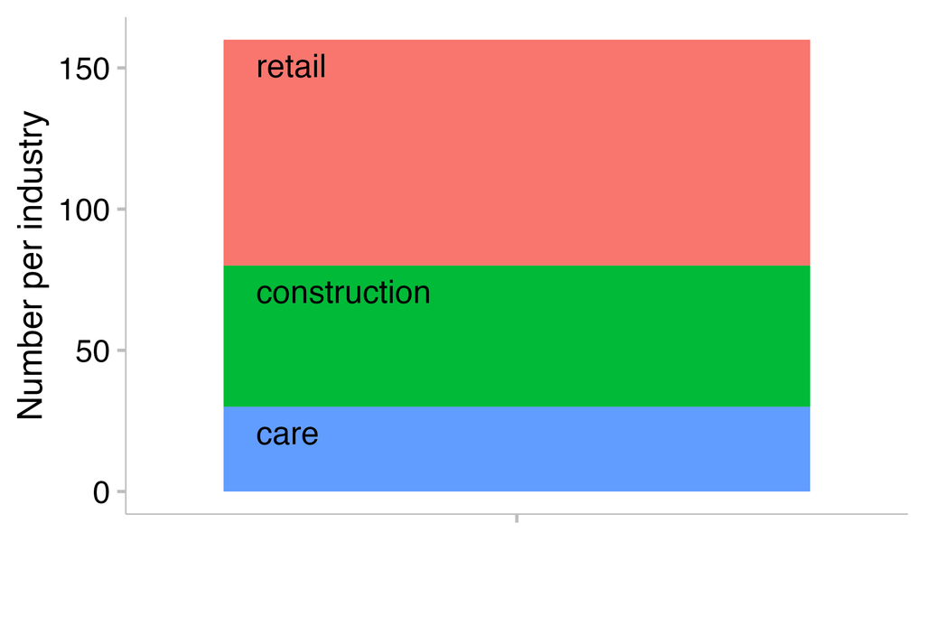

**Stacked percent**

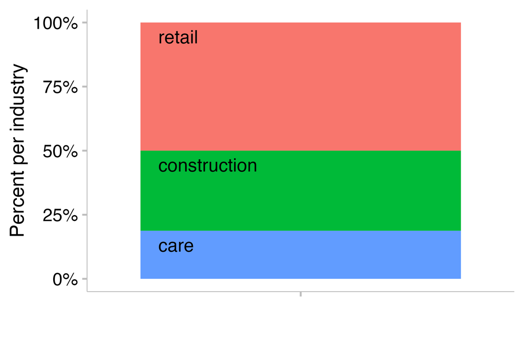

**Pie**

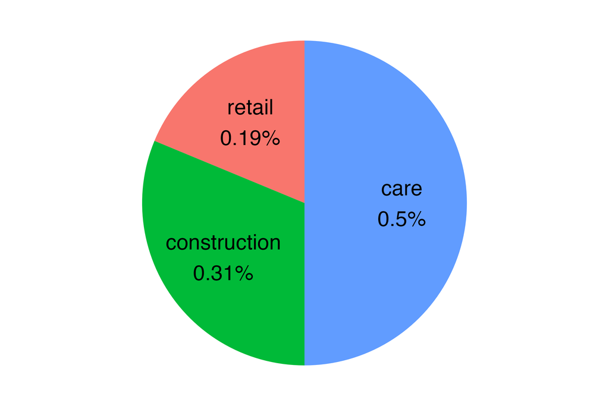